# L.A. Crime Scene Investigation: Data-Driven Detectives

## Exploratory Data Analysis

```r
library(dplyr)
names(crime_data)
```

```
##  [1] "DR_NO"        "Date.Rptd"    "DATE.OCC"     "TIME.OCC"     "AREA"
##  [6] "AREA.NAME"    "Crm.Cd"       "Crm.Cd.Desc"  "Vict.Age"     "Vict.Sex"
## [11] "Vict.Descent" "Weapon.Desc"  "LOCATION"     "LAT"          "LON"
```

```r
crime_frequency <- crime_data %>%
summarise(Frequency = n()) %>%
arrange(desc(Frequency))
```

Examining the Los Angeles Crime Dataset revealing the relationship between crime frequencies, victim descent, and geographic locations via variables like victim demographics, spatial coordinates, and crime classifications. This statistical explanation will make understand the patterns of investigation of crime patterns across demographic and spatial dimensions.

##Understanding through Plotting and Data Visualization.

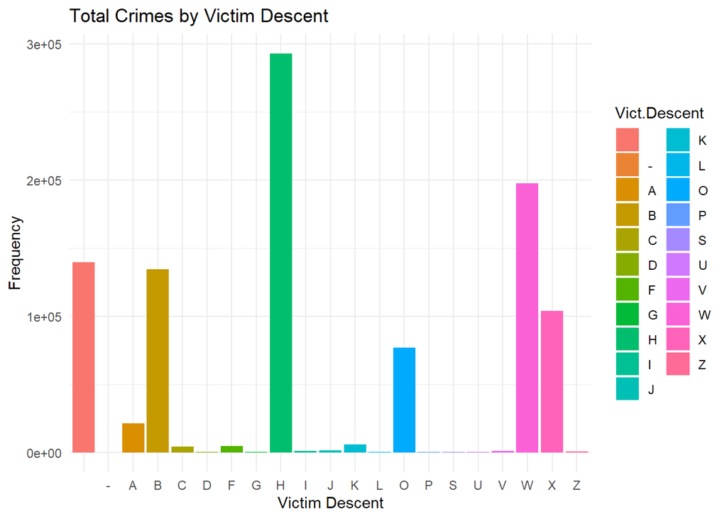

```r
crime_data %>%
  group_by(Vict.Descent) %>%
  summarise(Frequency = n()) %>%
  ggplot(aes(x = Vict.Descent, y = Frequency, fill = Vict.Descent)) +
  geom_bar(stat = "identity") +
  labs(title = "Total Crimes by Victim Descent", x = "Victim Descent", y = "Frequency") +
  theme_minimal()
```

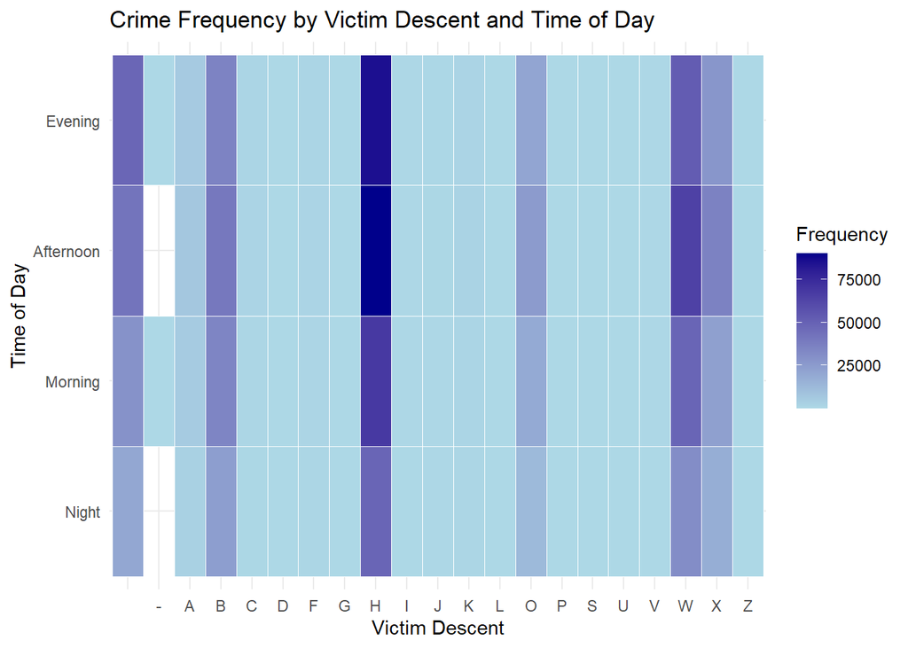

```r
crime_data$Time_Period <- cut(crime_data$TIME.OCC,
                              breaks = c(0, 600, 1200, 1800, 2400),
                              labels = c("Night", "Morning", "Afternoon", "Evening"))

crime_data %>%
  group_by(Vict.Descent, Time_Period) %>%
  summarise(Frequency = n()) %>%
  ggplot(aes(x = Vict.Descent, y = Time_Period, fill = Frequency)) +
  geom_tile(color = "white") +
  scale_fill_gradient(low = "lightblue", high = "darkblue") +
  labs(title = "Crime Frequency by Victim Descent and Time of Day", x = "Victim Descent", y = "Time of Day") +
  theme_minimal()
```

These patterns may indicate underlying socioeconomic factors, reporting tendencies, or demographic distribution within Los Angeles that merit further investigation for effective law enforcement resource allocation and community safety initiatives.

## Statistical Tests and further Inferences.

```r
library(dplyr)
library(tidyr)
unique_values <- unique(crime_data$Vict.Descent)
print(unique_values)
```

```
##  [1] "O" "X" "H" "B" "W" ""  "A" "K" "C" "J" "F" "I" "V" "S" "P" "Z" "G" "U" "D"
## [20] "L" "-"
```

```r
relevant_data <- crime_data %>%
  select(LON, LAT, Vict.Descent)
relevant_data$Vict.Descent <- as.factor(relevant_data$Vict.Descent)
dummy_data <- model.matrix(~ Vict.Descent - 1, data = relevant_data)
combined_data <- cbind(relevant_data[, c("LON", "LAT")], dummy_data)
cor_matrix <- cor(combined_data, use = "pairwise.complete.obs")
head(cor_matrix)
```

```
##                         LON           LAT  Vict.Descent Vict.Descent-
## LON            1.0000000000 -9.982402e-01 -0.0136292159 -7.614130e-05
## LAT           -0.9982402101  1.000000e+00  0.0127837340  9.362882e-05
## Vict.Descent  -0.0136292159  1.278373e-02  1.0000000000 -5.780537e-04
## Vict.Descent- -0.0000761413  9.362882e-05 -0.0005780537  1.000000e+00
## Vict.DescentA -0.0028852329  3.454959e-03 -0.0599913947 -2.104043e-04
## Vict.DescentB  0.0036809263 -1.209854e-02 -0.1612676539 -5.656045e-04
##               Vict.DescentA Vict.DescentB Vict.DescentC Vict.DescentD
## LON           -0.0028852329  0.0036809263 -2.623850e-03 -3.693233e-04
## LAT            0.0034549588 -0.0120985353  2.426118e-03  3.140438e-04
## Vict.Descent  -0.0599913947 -0.1612676539 -2.695578e-02 -3.834541e-03
## Vict.Descent- -0.0002104043 -0.0005656045 -9.454042e-05 -1.344866e-05
## Vict.DescentA  1.0000000000 -0.0586994019 -9.811565e-03 -1.395725e-03
## Vict.DescentB -0.0586994019  1.0000000000 -2.637525e-02 -3.751960e-03
##               Vict.DescentF Vict.DescentG Vict.DescentH Vict.DescentI
## LON           -1.550112e-03  2.095879e-03  0.0083479370 -4.044633e-05
## LAT            2.855431e-03 -2.080776e-03 -0.0057295432 -7.271047e-05
## Vict.Descent  -2.776303e-02 -3.468445e-03 -0.2639396383 -1.280211e-02
## Vict.Descent- -9.737163e-05 -1.216467e-05 -0.0009256999 -4.490009e-05
## Vict.DescentA -1.010539e-02 -1.262470e-03 -0.0960707155 -4.659808e-03
## Vict.DescentB -2.716511e-02 -3.393748e-03 -0.2582553547 -1.252640e-02
##               Vict.DescentJ Vict.DescentK Vict.DescentL Vict.DescentO
## LON           -0.0013186398 -0.0006730639 -3.305475e-04 -0.0012181055
## LAT            0.0008237343  0.0007093377  1.682008e-04  0.0053022226
## Vict.Descent  -0.0158743872 -0.0310036974 -3.492450e-03 -0.1181117979
## Vict.Descent- -0.0000556753 -0.0001087374 -1.224886e-05 -0.0004142465
## Vict.DescentA -0.0057780777 -0.0112849567 -1.271208e-03 -0.0429912120
## Vict.DescentB -0.0155325116 -0.0303359924 -3.417236e-03 -0.1155681066
##               Vict.DescentP Vict.DescentS Vict.DescentU Vict.DescentV
## LON           -0.0007686746 -2.983360e-04 -7.154174e-04 -3.665953e-04
## LAT            0.0008648773  7.305218e-05  6.175793e-04  5.053673e-04
## Vict.Descent  -0.0068283575 -3.031420e-03 -5.952060e-03 -1.373586e-02
## Vict.Descent- -0.0000239487 -1.063192e-05 -2.087531e-05 -4.817496e-05
## Vict.DescentA -0.0024854364 -1.103399e-03 -2.166475e-03 -4.999679e-03
## Vict.DescentB -0.0066813000 -2.966135e-03 -5.823875e-03 -1.344004e-02
##               Vict.DescentW Vict.DescentX Vict.DescentZ
## LON           -0.0047841866  0.0090284994 -1.329320e-03
## LAT            0.0084639516 -0.0113964919  1.547810e-03
## Vict.Descent  -0.2032925305 -0.1393417369 -9.474539e-03
## Vict.Descent- -0.0007129959 -0.0004887051 -3.322949e-05
## Vict.DescentA -0.0739959295 -0.0507186433 -3.448613e-03
## Vict.DescentB -0.1989143613 -0.1363408313 -9.270493e-03
```

```r
# ANOVA for Longitude
anova_lon <- aov(LON ~ Vict.Descent, data = crime_data)
summary(anova_lon)
```

```
##                  Df   Sum Sq Mean Sq F value Pr(>F)
## Vict.Descent     20    10754   537.7   16.78 <2e-16 ***
## Residuals    986479 31613033    32.0
## ---
## Signif. codes:  0 '***' 0.001 '**' 0.01 '*' 0.05 '.' 0.1 ' ' 1
```

```r
# ANOVA for Latitude
anova_lat <- aov(LAT ~ Vict.Descent, data = crime_data)
summary(anova_lat)
```

```
##                  Df  Sum Sq Mean Sq F value Pr(>F)
## Vict.Descent     20    1380   69.01   25.87 <2e-16 ***
## Residuals    986479 2631056    2.67
## ---
## Signif. codes:  0 '***' 0.001 '**' 0.01 '*' 0.05 '.' 0.1 ' ' 1
```

Coorelation Analysis reveals that there is potential geographic patterns in crime distribution across different demographic groups in Los Angeles, which is useful but not able to able to find exact coorelation to the spatial relationships in crime patterns by victim descent.

## Conclusion of SMART Question3: -

Based on the comprehensive analysis using ANOVA, correlation matrices, and visualizations:

Geographic Distribution: - ANOVA results indicate statistically notable differences in both latitude and longitude distributions across victim descent groups but not significant spatial patterns to validate the correlation.